# Final Project Visualizations 1

```r
library(tidyverse)
library(rio)
library(here)
library(gghighlight)
library(colorblindr)
library(janitor)
library(here)
library(zipcode)
library(viridis)
library(ggrepel)
#install.packages('zipcode')
#ST needed to install zipcode package first
```

```r
d <- import(here("data", "school_survey.sav"),
            setclass = "tbl_df") # %>%  characterize()
```

```r
d1<- d %>%
  select("school_county", 93:140) %>%
  mutate(school_county = tolower(school_county)) %>%
  rename(county = school_county) %>%
  factorize()

d2 <- d1 %>%
  group_by(county) %>%
  summarize(mean = mean(prepare))


map <- ggplot2::map_data("county") %>%
  filter(region == "oregon") %>%
  rename(county = subregion)
d1 %>%
  group_by(region_class_n, school_type_n) %>%
  count()
```

```
## # A tibble: 12 x 3
## # Groups:   region_class_n, school_type_n [12]
##    region_class_n school_type_n     n
##    <fct>          <fct>         <int>
##  1 Rural          Elementary       71
##  2 Rural          Middle School    27
##  3 Rural          High School      77
##  4 Rural          <NA>              1
##  5 Urban          Elementary      115
##  6 Urban          Middle School    39
##  7 Urban          High School      50
##  8 Urban          <NA>              7
##  9 Frontier       Elementary        4
## 10 Frontier       Middle School     1
## 11 Frontier       High School       9
## 12 <NA>           <NA>              1
```

```r
d1map <- left_join(map, d2)
d3 <- d1 %>%
  mutate(information_assistance_n = as.numeric(information_assistance_n)) %>%
  filter(!is.na(information_assistance_n)) %>%
  group_by(county) %>%
  summarize(mean = mean(information_assistance_n))

d2map <- left_join(map, d3)
d4 <- d1 %>%
  mutate(information_assistance_n = as.numeric(information_assistance_n))
```

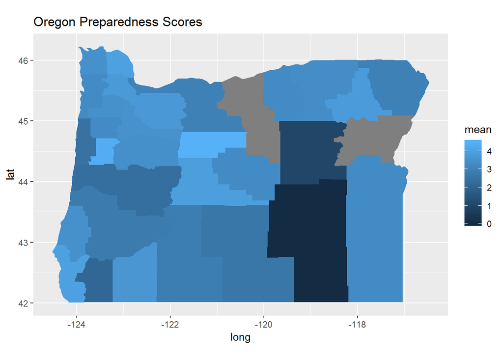

```r
ggplot() + geom_polygon(data = d1map, aes(x=long, y = lat, fill = mean, group = group)) +
  coord_fixed(1.3) +
  labs(title = "Oregon Preparedness Scores")
```

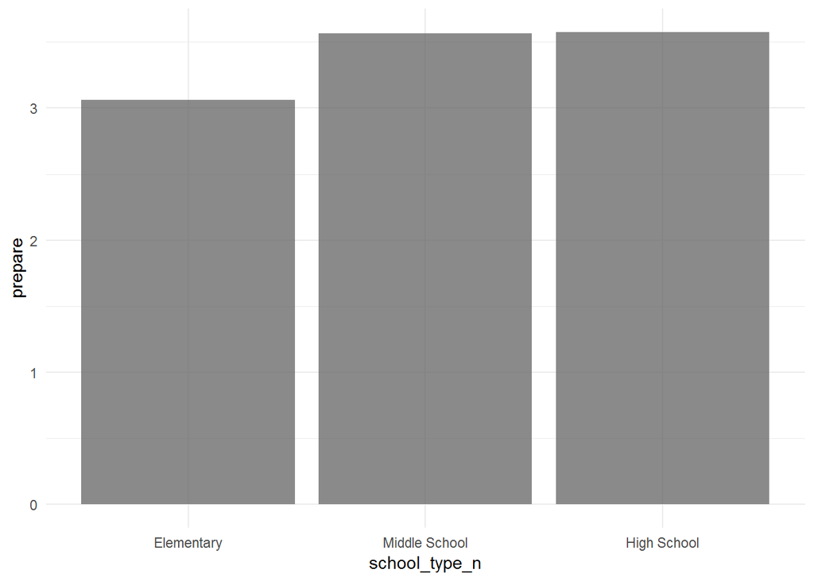

```r
d1 %>%
  filter(!is.na(school_type_n)) %>%
  ggplot(aes(school_type_n, prepare)) +
  theme_minimal() +
  scale_fill_viridis_d() +
  geom_bar(stat = "summary", fun.y = "mean", alpha = 0.7)
```

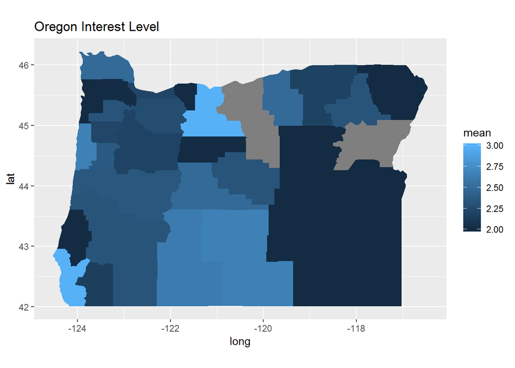

```r
ggplot() + geom_polygon(data = d2map, aes(x=long, y = lat, fill = mean, group = group)) +
  coord_fixed(1.3) +
  labs(title = "Oregon Interest Level")
```

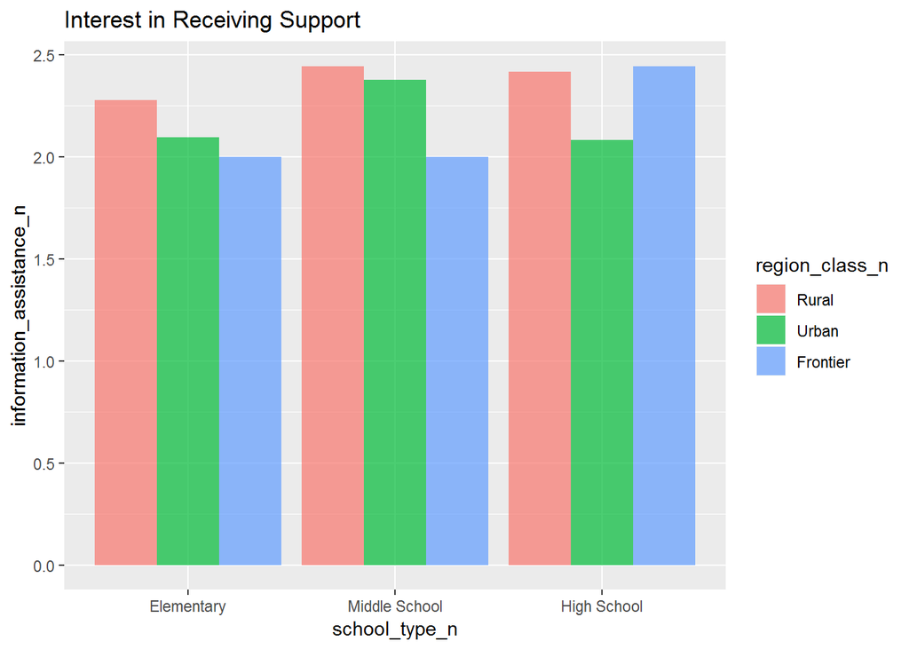

```r
d4 %>%
  filter(!is.na(school_type_n)) %>%
  ggplot(aes(school_type_n, information_assistance_n, fill = region_class_n)) +
  geom_bar(stat = "summary", fun.y = "mean", alpha = 0.7, position = "dodge") +
  labs(title = "Interest in Receiving Support")
```

## Visualization #1

This is the graph where it all started. I naturally have an affinity for all maps geographical and knew that whatever my portfolio entailed, it would most definitely include a “geom_polygon.” I started by creating a “preparedness composite score” that entailed scoring schools (0 = No, 1 = Yes) on the following five factors: (a) Postvention Plan, (b) EBP, (c) Memorandum of Understanding, (d) Identify and Refer Protocol, and (e) supplementary activities. Once the composite score was created, I to calculated the average for each county and then merged it with the map data. All of that was pretty straightforward. I have actually been surprised how (relatively) easy it has been working with maps, even in spite of them seeming intimidating. Once the data was merged and plotted, I ran into several obstacles. The first was a color scale that helped tell the story. I decided to go with viridis_c because of the Oregon green theme, although I agree with one of my reviewers that magma was clearer. The two other major issues that I battled with were (a) labels for the counties and (b) borders for the counties. For labels, I decided to finally go with label vs text and also incorporate the repel function. Without the use of repel, the county text is much more centered; however, the overlapping was way too messy. I am not completely sold on the labels vs plain text, but in terms of pure readability, it works much better. I am interested in whether you think that I should use county labels at all. They are distracting but practical. I also spent several hours trying to get the borders to come in as grey, but kept getting an error about continuous variables being needed. I had basically just added the same geom_polygon layer but had “fill = NA.” It did not work. This map will be shared with both lay people (our state agency clients and schools) and researchers (at a presentation at SPR). I am wondering whether the audience would change anything major for how a geom_polygon map is presented. Overall, I am happy with it, but will be interested to hear what you think. The more advice the better!

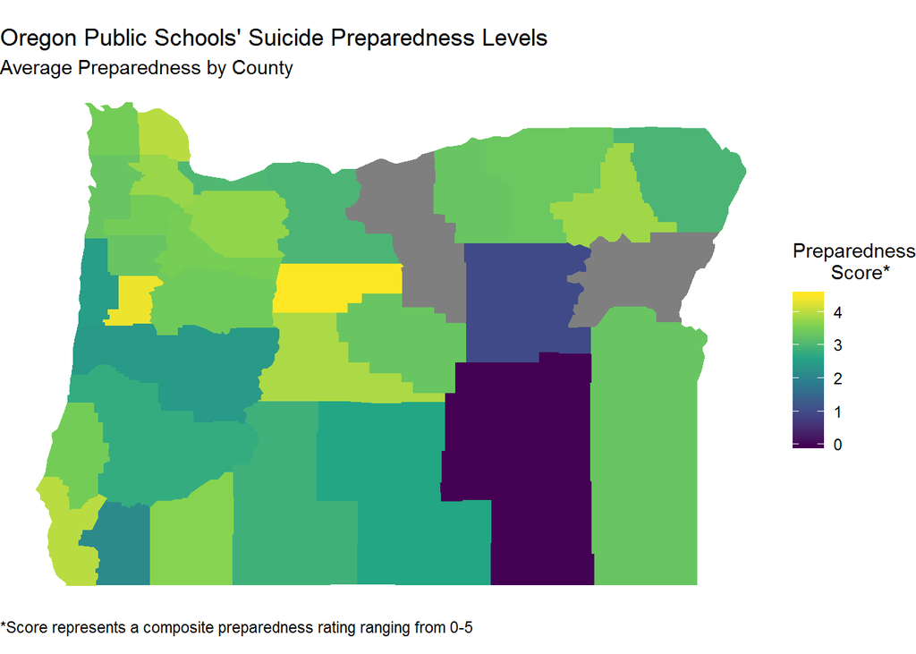

```r
ggplot() +
  geom_polygon(data = d1map, aes(x=long, y = lat, fill = mean, group = group)) +
  coord_fixed(1.3) +
  scale_fill_viridis_c()+ #ST personally, I think the magma option is easier to read
  theme_void() +
  theme(plot.caption = element_text(hjust = 0), #ST moving caption over
        axis.text = element_blank()) +
  labs(title = "Oregon Public Schools' Suicide Preparedness Levels",
       subtitle = "Average Preparedness by County", x = NULL, y = NULL,
       fill = "Preparedness
       Score*",
       caption = "*Score represents a composite preparedness rating ranging from 0-5")
```

```r
#ST Love this plot!!
```

```r
d1 <- d1 %>%
  mutate(school_type_n = recode(school_type_n, "Middle School" = "Middle",
                                               "High School" = "High"),
         region_class_n = factor(region_class_n,
                                 levels = c("Urban", "Rural", "Frontier"))) #ST combined into 1 mutate function
d1
```

```
## # A tibble: 402 x 49
##    county total_enrollment enrollment_k_3 enrollment_4_5 enrollment_6_8
##    <chr>             <dbl>          <dbl> <chr>          <chr>
##  1 washi~               NA             NA ""             ""
##  2 linn                 NA             NA ""             ""
##  3 clack~              230            150 80             --
##  4 colum~               24             13 11             --
##  5 coos                587            587 --             --
##  6 coos                386            386 --             --
##  7 coos                263            198 65             --
##  8 crook               620            402 218            --
##  9 desch~              381            227 154            --
## 10 dougl~              194            155 39             --
## # ... with 392 more rows, and 44 more variables:
## #   regular_attendance_pct <chr>, mobile_students_pct <dbl>,
## #   n_self_contained <chr>, ELA_class_size <dbl>, math_class_size <dbl>,
## #   ever_ELL_pct <chr>, economic_disadvntg_pct <chr>,
## #   disability_pct <dbl>, asian_pct <chr>, black_pct <chr>,
## #   hisp_pct <dbl>, native_am_pct <chr>, multi_racial_pct <dbl>,
## #   pac_islander_pct <chr>, white_pct <dbl>, languages_spoken_pct <dbl>,
## #   vaccinations_pct <dbl>, ela_pct_met <dbl>, on_track_fresh_17 <chr>,
## #   four_year_grade_rate_16 <dbl>, drop_out_16 <dbl>,
## #   continuing_ed_rate_15 <dbl>, school_level_n <fct>, job_title_n <fct>,
## #   identification_refer_n <fct>, postvention_plan_n <fct>,
## #   suicide_prevention_comfort_level_n <fct>,
## #   implementation_assistance_n <fct>, information_assistance_n <fct>,
## #   follow_up_n <fct>, school_type_n <fct>, number_programs <dbl>,
## #   complete <dbl>, number_mou <dbl>, number_suppplementary <dbl>,
## #   number_support <dbl>, number_barrier <dbl>,
## #   number_supplementary <dbl>, raw_prepare <dbl>, mous_d <dbl>,
## #   progs_d <dbl>, supps_d <dbl>, prepare <dbl>, region_class_n <fct>
```

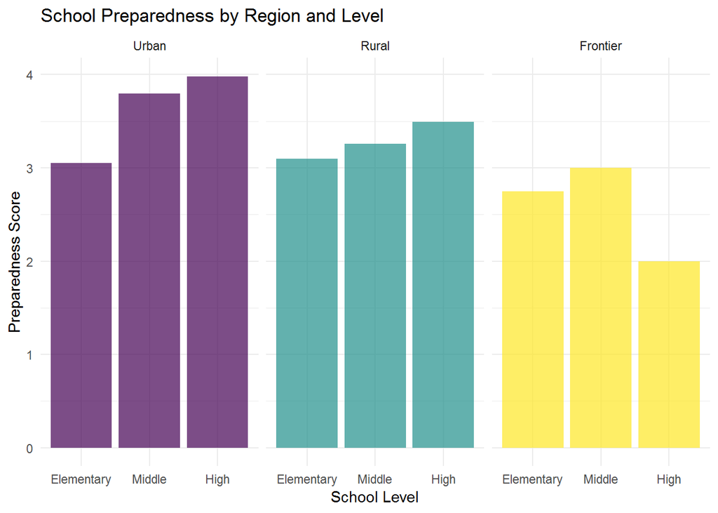

```r
d1 %>%
  filter(!is.na(school_type_n)) %>%
  ggplot(aes(school_type_n, prepare, fill = region_class_n)) + #I like the additional aesthetic of fill by region class, but can be dissuaded if it is distracting.
  #ST I also like the additional color!
  theme_minimal() +
  theme(legend.position = "none") +
  scale_fill_viridis_d() +
  geom_bar(stat = "summary", fun.y = "mean", alpha = 0.7) + #ST I haven't seen stat = "summary" used before. Does this plot the mean? - Great Job! I will be using this in the future.
  #geom_errorbar(aes(school_type_n, ymin = prepare - sd, ymax = prepare + sd), width=0.2, size=1, color="blue") +
  facet_wrap(~region_class_n) +
  labs(title = "School Preparedness by Region and Level",
       x = "School Level",
       y = "Preparedness Score")
```

```r
#ST I would consider changing some theme elements, such as making facet titles and axes text larger
```

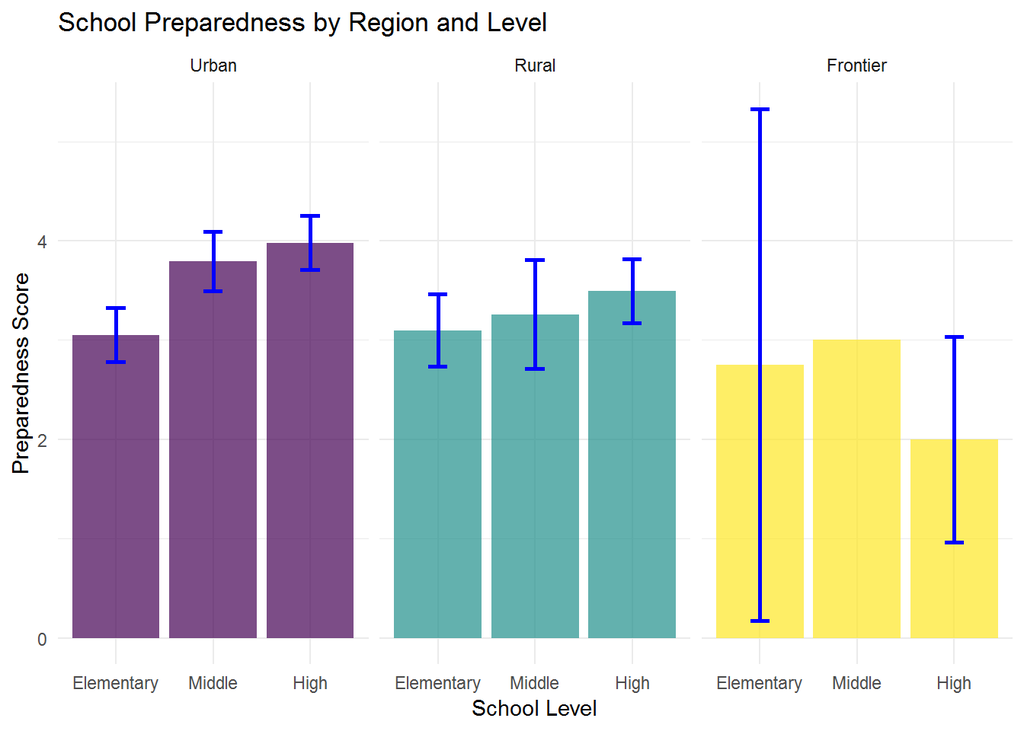

```r
d1 <- d1 %>%
  mutate(school_type_n = recode(school_type_n, "Middle School" = "Middle",
                                               "High School" = "High"),
         region_class_n = factor(region_class_n,
                                 levels = c("Urban", "Rural", "Frontier"))) %>% #ST combined into 1 mutate function
  filter(!is.na(school_type_n))

d1_sum <- d1 %>%
  group_by(region_class_n, school_type_n) %>%
  summarize(mean = mean(prepare, na.rm = TRUE),
            n = length(prepare),
            sd = sd(prepare, na.rm = TRUE),
            se = sd / sqrt(n), na.rm = TRUE)

ggplot() +
  geom_bar(data = d1, aes(school_type_n, prepare, fill = region_class_n), stat = "summary", fun.y = "mean", alpha = 0.7) +
  geom_errorbar(data = d1_sum, aes(ymin = mean + qnorm(.025)*se,
                                   ymax = mean + qnorm(.975)*se,
                                   x = school_type_n), width=0.2, size=1, color="blue") +
  facet_wrap(~region_class_n) +
  labs(title = "School Preparedness by Region and Level",
       x = "School Level",
       y = "Preparedness Score") +
  theme_minimal() +
  theme(legend.position = "none") +
  scale_fill_viridis_d()
```

```r
#ST not sure why there is still NAN values, but this code should work for errorbars
```

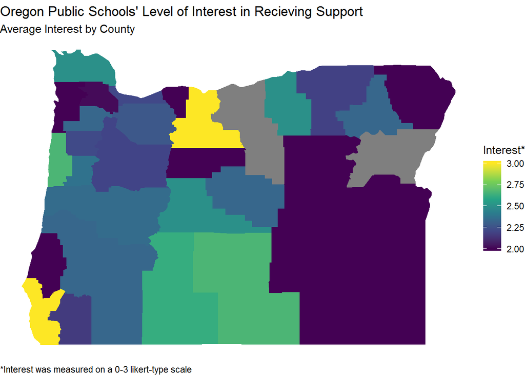

```r
ggplot() + geom_polygon(data = d2map, aes(x=long, y = lat, fill = mean, group = group)) +
  coord_fixed(1.3) +
  scale_fill_viridis_c() +
 theme_void() +
  theme(axis.text.x = element_blank(),
        axis.text.y = element_blank(),
        plot.caption = element_text(hjust = 0)) +
  labs(title = "Oregon Public Schools' Level of Interest in Recieving Support",
       subtitle = "Average Interest by County",
       x = NULL,
       y = NULL,
       fill = "Interest*", #ST added * to reference caption
       caption = "*Interest was measured on a 0-3 likert-type scale")
```

```r
#ST I love these plots - They look great!
```

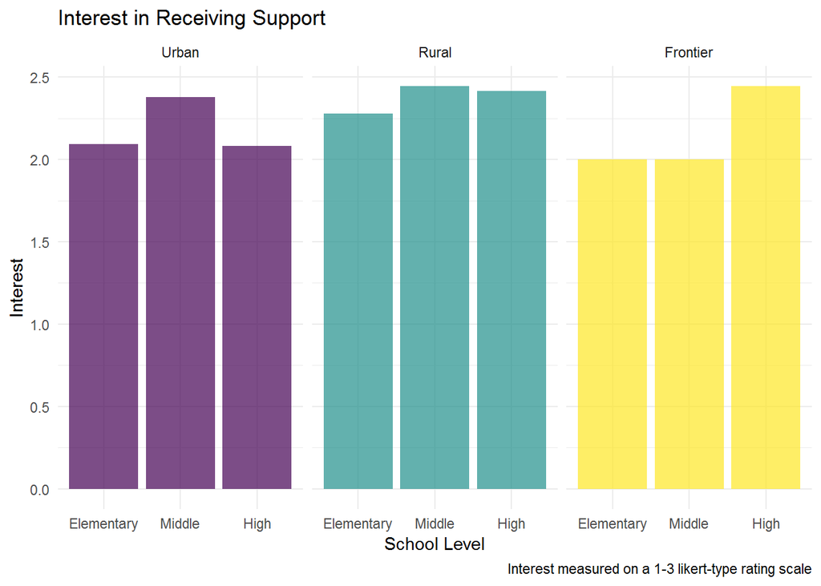

```r
d4 <- d1 %>%
  mutate(information_assistance_n = as.numeric(information_assistance_n))

d4 %>%
  filter(!is.na(school_type_n)) %>%
  ggplot(aes(school_type_n, information_assistance_n, fill = region_class_n)) + #I like the additional aesthetic of fill by region class, but can be dissuaded if it is distracting.
  theme_minimal() +
  theme(legend.position = "none") +
  scale_fill_viridis_d() +
  geom_bar(stat = "summary", fun.y = "mean", alpha = 0.7) +
  #geom_errorbar(aes(school_type_n, ymin = prepare - sd, ymax = prepare + sd), width=0.2, size=1, color="blue") +
  #ST you should be able to use the same code as above for the error bars here
  facet_wrap(~region_class_n) +
  labs(title = "Interest in Receiving Support",
       x = "School Level",
       y = "Interest",
       caption = "Interest measured on a 1-3 likert-type rating scale")
```

```r
cnames <- aggregate(cbind(long, lat) ~ county, data=d1map, FUN=function(x)mean(range(x))) %>%
   mutate(county = str_to_title(county))

cnames
```

```
##        county      long      lat
## 1       Baker -117.6426 44.67352
## 2      Benton -123.4237 44.49304
## 3   Clackamas -122.2520 45.16053
## 4     Clatsop -123.6586 45.99419
## 5    Columbia -123.0685 45.93689
## 6        Coos -124.0683 43.13513
## 7       Crook -120.3784 44.12061
## 8       Curry -124.1256 42.48196
## 9   Deschutes -120.9485 43.99456
## 10    Douglas -123.0799 43.30988
## 11    Gilliam -120.2065 45.43269
## 12      Grant -118.9460 44.47585
## 13     Harney -119.0664 43.02913
## 14 Hood River -121.6790 45.47566
```

[output cut: 22 more lines]

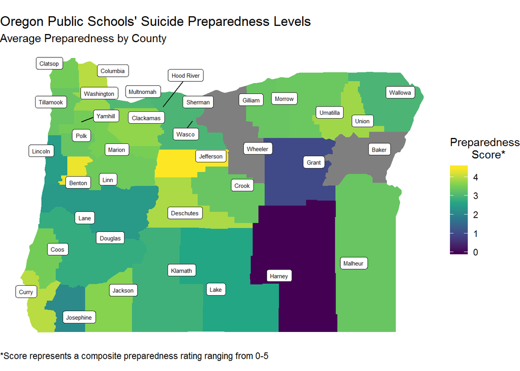

```r
ggplot() +
  geom_polygon(data = d1map, aes(x=long, y = lat, fill = mean, group = group)) +
  coord_fixed(1.3) +
  geom_label_repel(data =cnames, aes(long, lat, label = county), size = 2, color = "grey1") +
  scale_fill_viridis_c() + #ST personally, I think the magma option is easier to read
  theme_void() +
  theme(plot.caption = element_text(hjust = 0), #ST moving caption over
        axis.text = element_blank()) +
  labs(title = "Oregon Public Schools' Suicide Preparedness Levels",
       subtitle = "Average Preparedness by County", x = NULL, y = NULL,
       fill = "Preparedness
       Score*",
       caption = "*Score represents a composite preparedness rating ranging from 0-5")
```

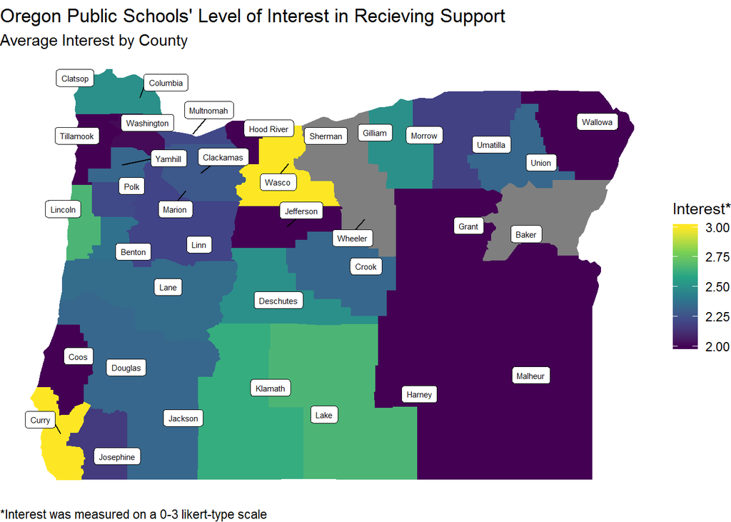

```r
ggplot() + geom_polygon(data = d2map, aes(x=long, y = lat, fill = mean, group = group)) +
  coord_fixed(1.3) +
  scale_fill_viridis_c() +
  geom_label_repel(data =cnames, aes(long, lat, label = county), size = 2, color = "grey1") +
 theme_void() +
  theme(axis.text.x = element_blank(),
        axis.text.y = element_blank(),
        plot.caption = element_text(hjust = 0)) +
  labs(title = "Oregon Public Schools' Level of Interest in Recieving Support",
       subtitle = "Average Interest by County",
       x = NULL,
       y = NULL,
       fill = "Interest*", #ST added * to reference caption
       caption = "*Interest was measured on a 0-3 likert-type scale")
```

```r
#ST I love these plots - They look great!
```